# Exploratory Data Analysis

Published

September 22, 2025

# 1. Time Series Plot

**Total TEUs**

```r
library(dplyr)
library(lubridate)
library(plotly)
library(ggplot2)
raw <- read.csv("data-raw/la_teu_data.csv", stringsAsFactors = FALSE)

num_cols <- c("Loaded_Imports","Empty_Imports","Total_Imports",
              "Loaded_Exports","Empty_Exports","Total_Exports","Total_TEUs")

Sys.setlocale("LC_TIME", "C")
```

```
[1] "C"
```

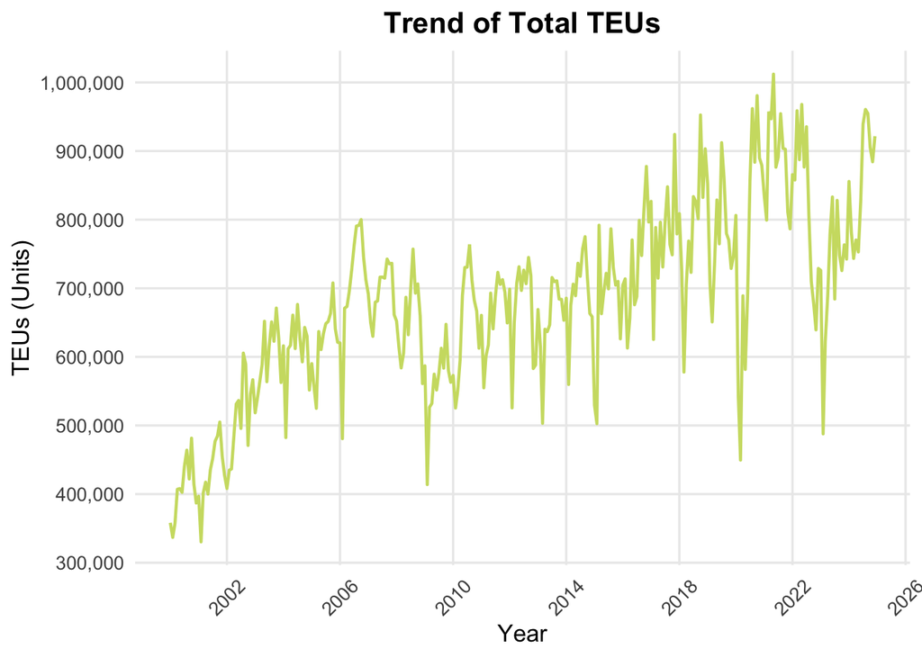

```r
la_teu <- raw %>%
  mutate(
    Date = my(Date),
    across(all_of(num_cols), ~ as.numeric(gsub(",", "", .))),
    Prior_Year_Change = suppressWarnings(as.numeric(sub("%","", Prior_Year_Change))) / 100,
    Empty_Containers = Empty_Imports + Empty_Exports,
    Total_calc = Loaded_Imports + Loaded_Exports + Empty_Containers,
    Total_TEUs = ifelse(is.na(Total_TEUs), Total_calc, Total_TEUs)
  ) %>%
  arrange(Date) %>%
  filter(Date >= as.Date("2000-01-01"))

plot1 <- ggplot(data = la_teu, aes(x = Date, y = Total_TEUs)) +
  geom_line(color = "#cddd71", linewidth = 0.8) +
  scale_y_continuous(
    name = "TEUs (Units)",
    labels = scales::comma,
    breaks = scales::pretty_breaks(n = 6)
  ) +
  scale_x_date(
    date_breaks = "4 year",
    date_labels = "%Y"
  ) +
  labs(
    x = "Year",
    title = "Trend of Total TEUs"
  ) +
  theme_minimal(base_size = 13) +
  theme(
    plot.title = element_text(face = "bold", size = 16, hjust = 0.5),
    axis.text.x = element_text(angle = 45, vjust = 0.5),
    panel.grid.minor = element_blank()
  )

plot1
```

The total port throughput has shown a steady upward trend since 2000, reflecting the continuous expansion of maritime trade activities. Noticeable cyclical fluctuations are present, with sharp declines around the 2008 global financial crisis and the 2020 COVID-19 pandemic, indicating the port’s sensitivity to global economic shocks.

Overall, the sustained increase highlights the port’s growing role in international trade and supply chain logistics. Given the pronounced trend and high variability, applying log transformation or differencing would help stabilize variance and mitigate the impact of extreme values, making the data more suitable for time-series modeling and forecasting.

**Loaded Imports**

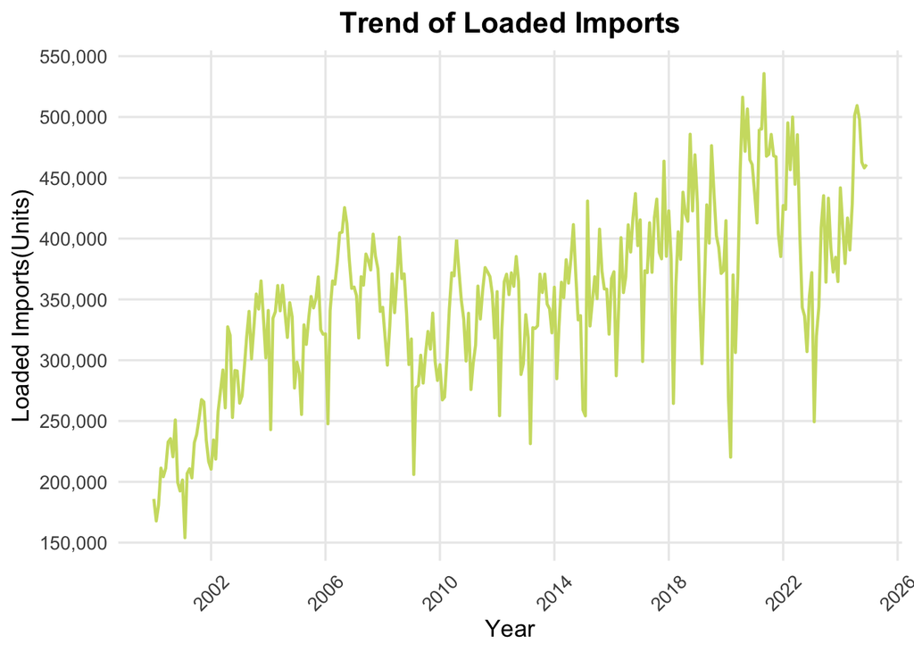

```r
plot2 <- ggplot(data = la_teu, aes(x = Date, y = Loaded_Imports)) +
  geom_line(color = "#cddd71", linewidth = 0.8) +
  scale_y_continuous(
    name = "Loaded Imports(Units)",
    labels = scales::comma,
    breaks = scales::pretty_breaks(n = 6)
  ) +
  scale_x_date(
    date_breaks = "4 year",
    date_labels = "%Y"
  ) +
  labs(
    x = "Year",
    title = "Trend of Loaded Imports"
  ) +
  theme_minimal(base_size = 13) +
  theme(
    plot.title = element_text(face = "bold", size = 16, hjust = 0.5),
    axis.text.x = element_text(angle = 45, vjust = 0.5),
    panel.grid.minor = element_blank()
  )

plot2
```

Loaded imports exhibit a clear long-term upward trajectory, suggesting increasing dependence of U.S. domestic demand and manufacturing on imported goods. The series displays strong seasonality and cyclical fluctuations — with higher volumes typically observed toward the end of each year and during major shopping seasons — while sharp drops in 2008 and 2020 correspond to major economic disruptions.

Although the overall direction remains upward, short-term volatility is considerable. For further analysis, smoothing or seasonal adjustment may be applied to extract the underlying trend and assess how import volumes respond to external factors such as energy prices or the U.S. dollar index.

**Loaded Exports**

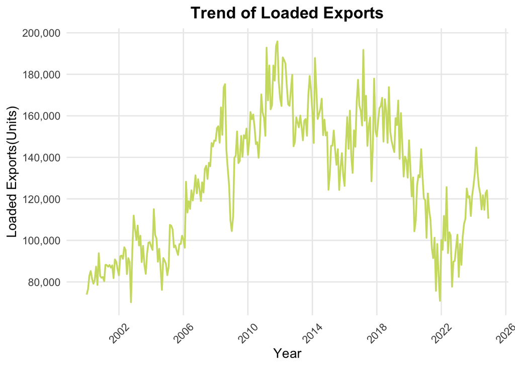

```r
plot3 <- ggplot(data = la_teu, aes(x = Date, y = Loaded_Exports)) +
  geom_line(color = "#cddd71", linewidth = 0.8) +
  scale_y_continuous(
    name = "Loaded Exports(Units)",
    labels = scales::comma,
    breaks = scales::pretty_breaks(n = 6)
  ) +
  scale_x_date(
    date_breaks = "4 year",
    date_labels = "%Y"
  ) +
  labs(
    x = "Year",
    title = "Trend of Loaded Exports"
  ) +
  theme_minimal(base_size = 13) +
  theme(
    plot.title = element_text(face = "bold", size = 16, hjust = 0.5),
    axis.text.x = element_text(angle = 45, vjust = 0.5),
    panel.grid.minor = element_blank()
  )

plot3
```

**Brent Crude Oil Price**

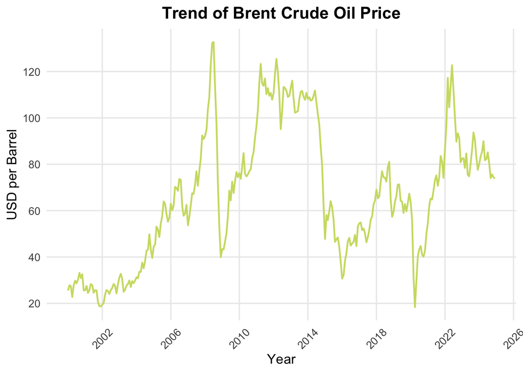

```r
library(readr)
library(dplyr)
brent <- read_csv("data-raw/brent.csv", show_col_types = FALSE)
WTI   <- read_csv("data-raw/WTI.csv", show_col_types = FALSE)
usd   <- read_csv("data-raw/usd.csv", show_col_types = FALSE)
rmb   <- read_csv("data-raw/rmb.csv", show_col_types = FALSE)

brent <- brent %>%
  rename(Date = observation_date, Price = MCOILBRENTEU)
usd <- usd %>%
  rename(Date = observation_date, Index = DTWEXBGS)

plot4 <- ggplot(data = brent, aes(x = Date, y = Price)) +
  geom_line(color = "#cddd71", linewidth = 0.8) +
  scale_y_continuous(
    name = "USD per Barrel",
    labels = scales::comma,
    breaks = scales::pretty_breaks(n = 6)
  ) +
  scale_x_date(
    date_breaks = "4 year",
    date_labels = "%Y"
  ) +
  labs(
    x = "Year",
    title = "Trend of Brent Crude Oil Price"
  ) +
  theme_minimal(base_size = 13) +
  theme(
    plot.title = element_text(face = "bold", size = 16, hjust = 0.5),
    axis.text.x = element_text(angle = 45, vjust = 0.5),
    panel.grid.minor = element_blank()
  )

plot4
```

The Brent crude oil price exhibits significant volatility since 2000, with major peaks around 2008 and 2022 corresponding to the pre-financial-crisis surge and the Russia–Ukraine conflict, respectively. Sharp declines in 2014 and 2020 reflect global supply–demand shocks and geopolitical instability in energy markets.

Overall, the series shows a cyclical pattern driven by macroeconomic and geopolitical factors. To analyze the long-term influence of oil prices on trade costs, applying log transformation or smoothing may help reduce extreme fluctuations and stabilize variance for modeling.

**U.S. Dollar Index**

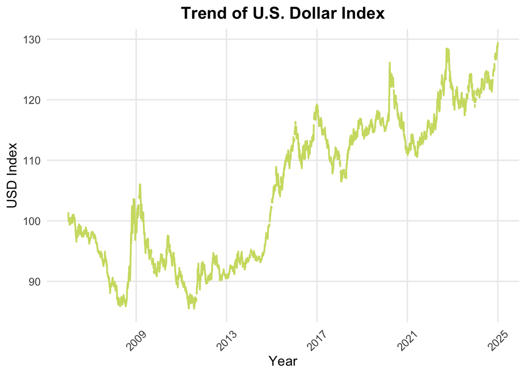

```r
plot5 <- ggplot(data = usd , aes(x = Date, y = Index)) +
  geom_line(color = "#cddd71", linewidth = 0.8) +
  scale_y_continuous(
    name = "USD Index",
    labels = scales::comma,
    breaks = scales::pretty_breaks(n = 6)
  ) +
  scale_x_date(
    date_breaks = "4 year",
    date_labels = "%Y"
  ) +
  labs(
    x = "Year",
    title = "Trend of U.S. Dollar Index"
  ) +
  theme_minimal(base_size = 13) +
  theme(
    plot.title = element_text(face = "bold", size = 16, hjust = 0.5),
    axis.text.x = element_text(angle = 45, vjust = 0.5),
    panel.grid.minor = element_blank()
  )

plot5
```

Since a stronger dollar tends to reduce import costs but weaken export competitiveness, its fluctuations may affect port trade volumes. In subsequent analysis, differencing or trend decomposition can be applied to isolate the cyclical impact of currency movements on port throughput.

**Global Supply Chain Pressure Index**

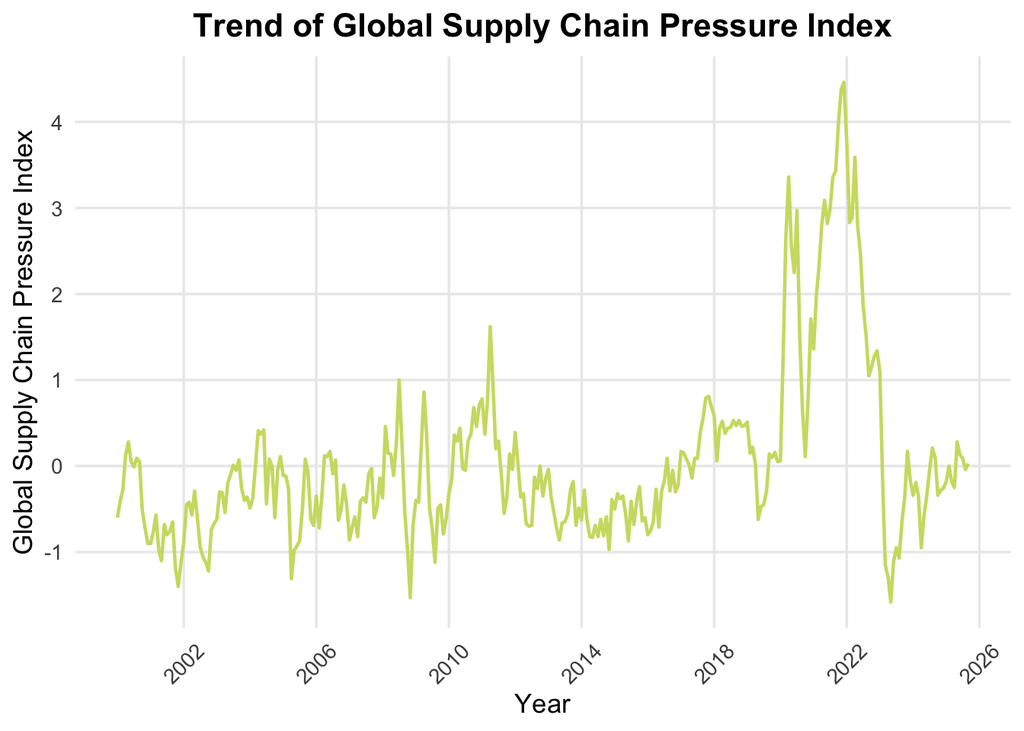

```r
gscpi <- read_csv(
  "data-raw/GSCPI.csv",
  col_types = cols(
    Date  = col_date(format = "%d-%b-%Y"),  # 31-Jan-1998
    GSCPI = col_double()
  ),
  show_col_types = FALSE
) %>%
  mutate(Date = floor_date(Date, "month")) %>%
  filter(Date >= as.Date("2000-01-01"))

plot6 <- ggplot(data = gscpi , aes(x = Date, y = GSCPI)) +
  geom_line(color = "#cddd71", linewidth = 0.8) +
  scale_y_continuous(
    name = "Global Supply Chain Pressure Index",
    labels = scales::comma,
    breaks = scales::pretty_breaks(n = 6)
  ) +
  scale_x_date(
    date_breaks = "4 year",
    date_labels = "%Y"
  ) +
  labs(
    x = "Year",
    title = "Trend of Global Supply Chain Pressure Index"
  ) +
  theme_minimal(base_size = 13) +
  theme(
    plot.title = element_text(face = "bold", size = 16, hjust = 0.5),
    axis.text.x = element_text(angle = 45, vjust = 0.5),
    panel.grid.minor = element_blank()
  )

plot6
```

The Global Supply Chain Pressure Index remains relatively stable near zero over time but spikes sharply during major global disruptions such as the 2008 financial crisis, the COVID-19 pandemic, and the 2021–2022 logistics bottlenecks. The extreme peaks indicate severe supply chain stress and transportation bottlenecks worldwide.

Given its volatility and external nature, this index serves as a valuable exogenous variable to capture the impact of global supply chain disruptions on port throughput dynamics.

**AHS Weighted Average Tariff**

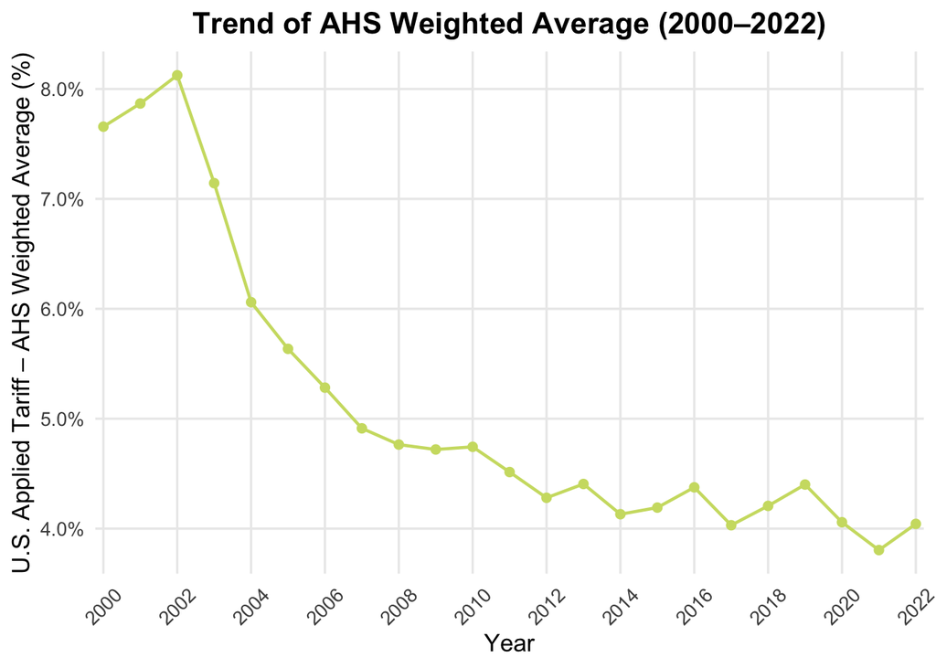

```r
library(readr)
library(dplyr)
library(ggplot2)
library(scales)

ahs_y <- read_csv("data-raw/ahs.csv", show_col_types = FALSE) %>%
  rename(
    Year = Date,
    Tariff = `AHS Weighted Average (%)`
  ) %>%
  filter(Year >= 2000, Year <= 2022)

plot7<- ggplot(data = ahs_y, aes(x = Year, y = Tariff)) +
  geom_line(color = "#cddd71", linewidth = 0.8) +
  geom_point(color = "#cddd71", size = 2) +
  scale_x_continuous(
    breaks = seq(2000, 2022, by = 2),
    expand = expansion(mult = c(0.01, 0.01))
  ) +
  scale_y_continuous(
    name = "U.S. Applied Tariff – AHS Weighted Average (%)",
    labels = label_number(accuracy = 0.1, suffix = "%"),
    breaks = pretty_breaks(n = 6)
  ) +
  labs(
    x = "Year",
    title = "Trend of AHS Weighted Average (2000–2022)"
  ) +
  theme_minimal(base_size = 13) +
  theme(
    plot.title = element_text(face = "bold", size = 16, hjust = 0.5),
    axis.text.x = element_text(angle = 45, vjust = 0.5),
    panel.grid.minor = element_blank()
  )

plot7
```

The U.S. applied tariff, measured by the AHS weighted average, shows a persistent downward trend since 2000, declining from around 8% to 4%. The reduction coincides with major trade liberalization efforts, particularly following China’s WTO accession in 2001.

This steady decline indicates a structural easing of trade barriers, which has facilitated import expansion over time. In modeling, the tariff rate can be treated as a policy variable to explore its long-run cointegration with import volume and overall port activity.

**S&P 500 Index**

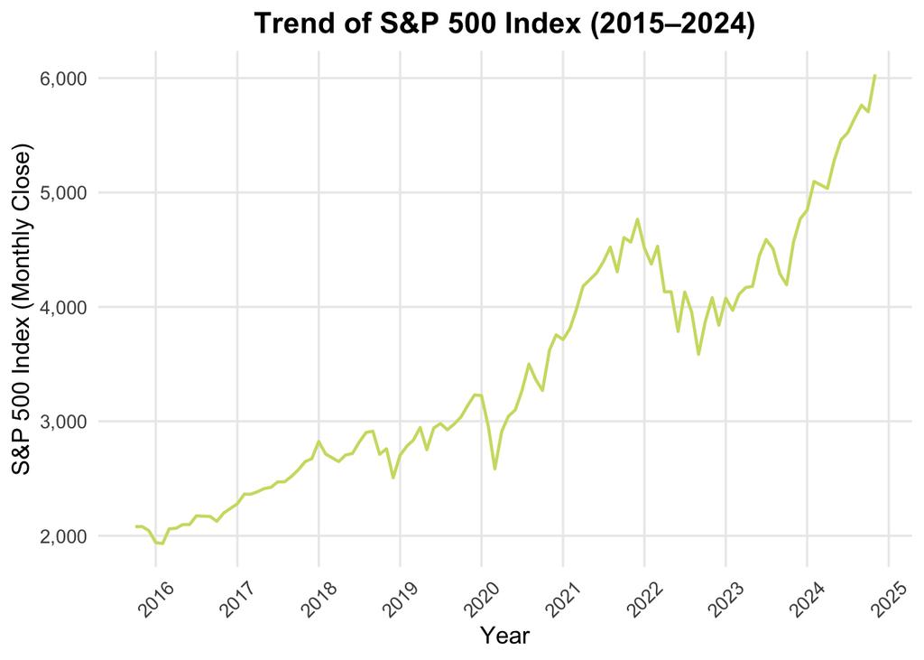

```r
library(readr)
library(dplyr)
library(lubridate)
library(ggplot2)
library(scales)

sp500 <- read_csv("data-raw/sp500.csv") %>%
  mutate(Date = as.Date(observation_date)) %>%
  filter(Date >= as.Date("2015-10-01") & Date <= as.Date("2024-12-01")) %>%
  mutate(Year = year(Date), Month = month(Date)) %>%
  group_by(Year, Month) %>%
  slice_max(Date) %>%
  ungroup() %>%
  mutate(YearMonth = as.Date(paste0(Year, "-", Month, "-01"))) %>%
  select(YearMonth, SP500)
sp500_clean <- sp500 %>%
  filter(!is.na(SP500))

plot8 <- ggplot(sp500_clean, aes(x = YearMonth, y = SP500)) +
  geom_line(color = "#cddd71", linewidth = 0.8) +
  scale_y_continuous(
    name = "S&P 500 Index (Monthly Close)",
    labels = scales::comma,
    breaks = scales::pretty_breaks(n = 6)
  ) +
  scale_x_date(
    date_breaks = "1 year",
    date_labels = "%Y"
  ) +
  labs(
    x = "Year",
    title = "Trend of S&P 500 Index (2015–2024)"
  ) +
  theme_minimal(base_size = 13) +
  theme(
    plot.title = element_text(face = "bold", size = 16, hjust = 0.5),
    axis.text.x = element_text(angle = 45, vjust = 0.5),
    panel.grid.minor = element_blank()
  )

plot8
```

Between 2015 and 2024, the S&P 500 Index demonstrates a strong upward trend, reflecting the sustained expansion of the U.S. capital market. Despite a brief decline during the COVID-19 outbreak in 2020, the index rebounded rapidly and reached record highs by 2024, largely driven by the growth of technology sectors and accommodative monetary policy.

This pattern underscores the S&P 500’s role as a key indicator of macroeconomic health and investor sentiment. In subsequent modeling, it can serve as a proxy for financial market expectations, helping to capture the interdependence between trade activity and market confidence.

**U.S. Retail & Food Services Sales**

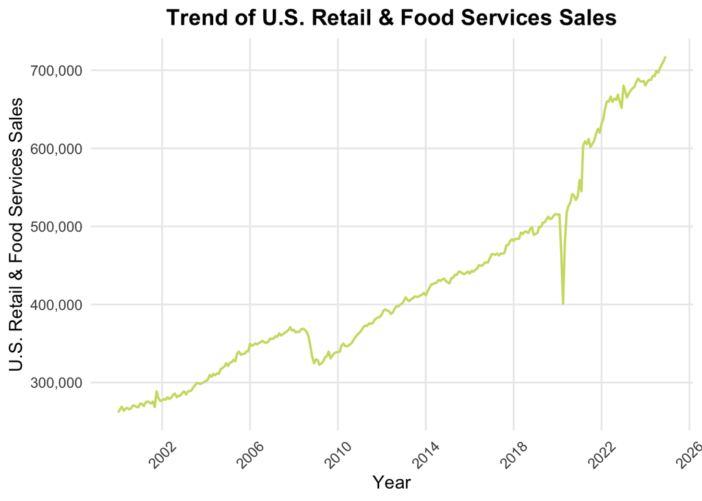

```r
rsafs<- read_csv("data-raw/RSAFS.csv")
rsafs <- rsafs%>%
  mutate(Date = as.Date(observation_date)) %>%
  select(Date, RSAFS)

plot9 <- ggplot(data =rsafs , aes(x = Date, y = RSAFS)) +
  geom_line(color = "#cddd71", linewidth = 0.8) +
  scale_y_continuous(
    name = "U.S. Retail & Food Services Sales",
    labels = scales::comma,
    breaks = scales::pretty_breaks(n = 6)
  ) +
  scale_x_date(
    date_breaks = "4 year",
    date_labels = "%Y"
  ) +
  labs(
    x = "Year",
    title = "Trend of U.S. Retail & Food Services Sales"
  ) +
  theme_minimal(base_size = 13) +
  theme(
    plot.title = element_text(face = "bold", size = 16, hjust = 0.5),
    axis.text.x = element_text(angle = 45, vjust = 0.5),
    panel.grid.minor = element_blank()
  )

plot9
```

U.S. Retail & Food Services Sales show a steady long-term increase since 2000, indicating sustained growth in household spending and domestic demand. Temporary declines during the 2008 financial crisis and the 2020 pandemic were followed by rapid recoveries, with post-pandemic fiscal stimulus pushing sales to record levels.

This variable captures both a persistent upward trend and short-term fluctuations, making it a strong indicator of domestic demand strength. In modeling, it can be employed as a macro-demand variable to explore the long-run linkage between port import volumes and internal consumption dynamics.

Based on the time series patterns observed in the nine plots, several variables display clear upward trends, cyclical fluctuations, and varying degrees of volatility. To enhance model performance and interpretability, a log transformation will be applied to variables with strong growth patterns or high variance, including Total TEUs, Loaded Imports, Loaded Exports, Brent Crude Oil Price, and U.S. Retail & Food Services Sales. This transformation helps stabilize variance, mitigate the influence of extreme values, and linearize multiplicative growth relationships that are common in trade and price data.

# 2. Lag plot

**Total TEUs**

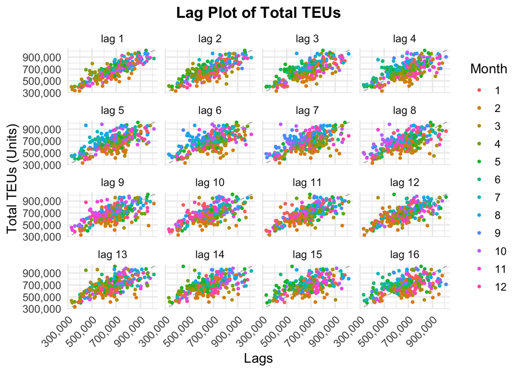

```r
library(forecast)
library(ggplot2)
library(scales)

la_teu_ts <- ts(la_teu$Total_TEUs, start = c(2000, 1), frequency = 12)

gglagplot(la_teu_ts, do.lines = FALSE) +
  xlab("Lags") +
  ylab("Total TEUs (Units)") +
  ggtitle("Lag Plot of Total TEUs") +
  scale_x_continuous(labels = comma) +
  scale_y_continuous(labels = comma) +
  theme_minimal(base_size = 13) +
  theme(
    axis.text.x = element_text(angle = 45, hjust = 1),
    plot.title = element_text(face = "bold", size = 15, hjust = 0.5)
  )
```

The lag plot of Total TEUs shows a strong positive autocorrelation across multiple lags, with noticeable clustering along the diagonal line. This indicates that past monthly throughput strongly predicts future levels, suggesting persistent growth patterns and potential unit-root behavior. The consistent spread across seasons reflects stable cyclical activity, implying non-stationarity that may require differencing or log transformation for modeling.

**Loaded Imports**

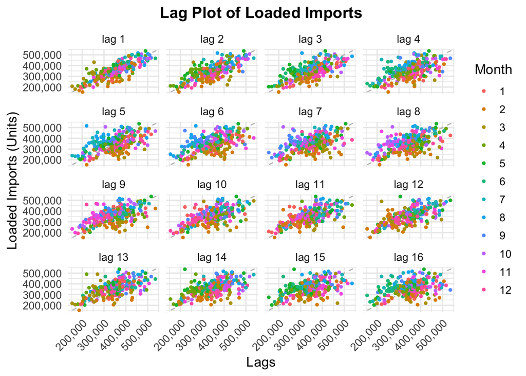

```r
la_li_ts <- ts(la_teu$Loaded_Imports, start = c(2000, 1), frequency = 12)
gglagplot(la_li_ts, do.lines = FALSE) +
  xlab("Lags") +
  ylab("Loaded Imports (Units)") +
  ggtitle("Lag Plot of Loaded Imports") +
  scale_x_continuous(labels = comma) +
  scale_y_continuous(labels = comma) +
  theme_minimal(base_size = 13) +
  theme(
    axis.text.x = element_text(angle = 45, hjust = 1),
    plot.title = element_text(face = "bold", size = 15, hjust = 0.5)
  )
```

The lag plot of Loaded Imports reveals a strong and stable autocorrelation pattern, particularly evident at shorter lags. The dense linear clustering suggests persistent import activity and seasonal cycles within each year. However, the gradual dispersion at longer lags implies mild trend shifts over time. The overall pattern indicates non-stationary behavior with a strong seasonal component, making seasonal differencing an appropriate transformation step.

**Loaded Exports**

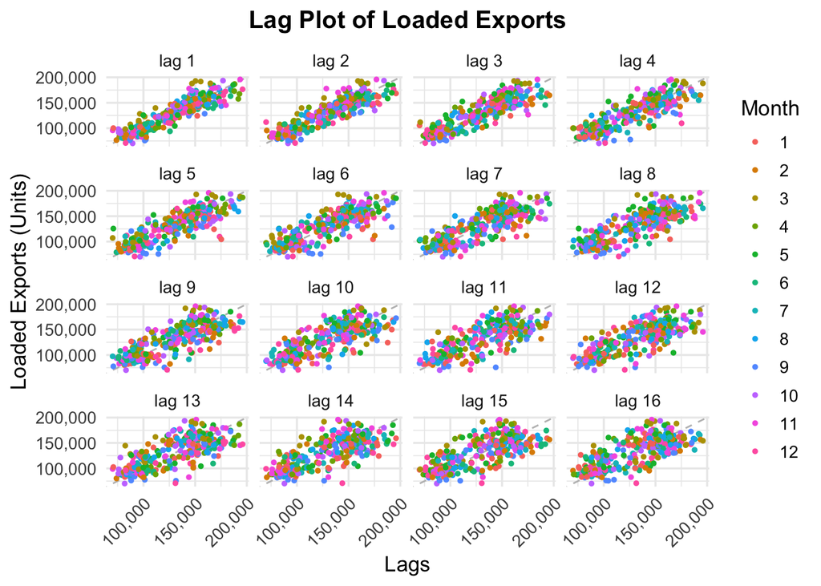

```r
la_le_ts <- ts(la_teu$Loaded_Exports, start = c(2000, 1), frequency = 12)
gglagplot(la_le_ts, do.lines = FALSE) +
  xlab("Lags") +
  ylab("Loaded Exports (Units)") +
  ggtitle("Lag Plot of Loaded Exports") +
  scale_x_continuous(labels = comma) +
  scale_y_continuous(labels = comma) +
  theme_minimal(base_size = 13) +
  theme(
    axis.text.x = element_text(angle = 45, hjust = 1),
    plot.title = element_text(face = "bold", size = 15, hjust = 0.5)
  )
```

**Brent Crude Oil Price**

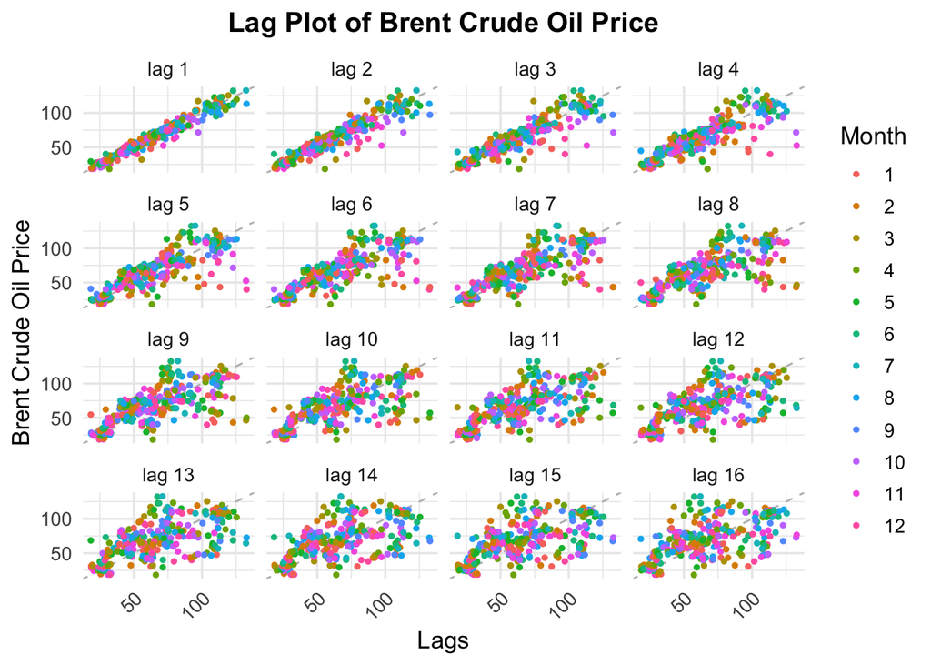

```r
brent_ts <- ts(brent$Price, start = c(2000, 1), frequency = 12)
gglagplot(brent_ts, do.lines = FALSE) +
  xlab("Lags") +
  ylab("Brent Crude Oil Price") +
  ggtitle("Lag Plot of Brent Crude Oil Price") +
  scale_x_continuous(labels = comma) +
  scale_y_continuous(labels = comma) +
  theme_minimal(base_size = 13) +
  theme(
    axis.text.x = element_text(angle = 45, hjust = 1),
    plot.title = element_text(face = "bold", size = 15, hjust = 0.5)
  )
```

The lag plot of Brent Crude Oil Price exhibits strong positive autocorrelation at short lags, with points forming a clear diagonal pattern. This indicates that oil prices are highly persistent and influenced by their recent values. However, the dispersion increases at higher lags, suggesting the presence of market shocks and cyclical adjustments over time. The combination of persistence and volatility implies non-stationarity, making log transformation and differencing suitable preprocessing steps for modeling.

**U.S. Dollar Index**

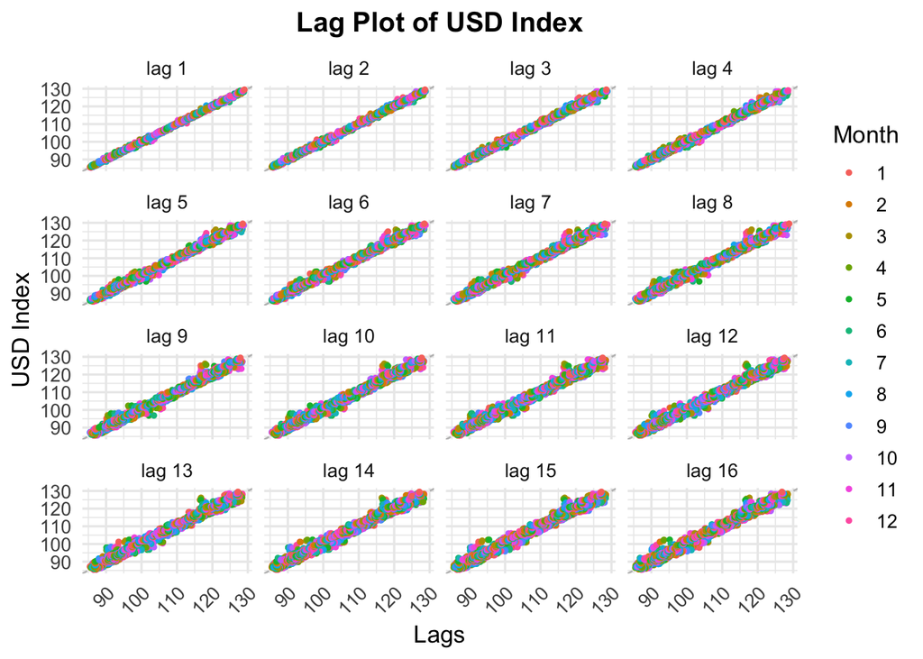

```r
usd_ts <- ts(usd$Index, start = c(2000, 1), frequency = 12)
gglagplot(usd_ts, do.lines = FALSE) +
  xlab("Lags") +
  ylab("USD Index") +
  ggtitle("Lag Plot of USD Index") +
  scale_x_continuous(labels = comma) +
  scale_y_continuous(labels = comma) +
  theme_minimal(base_size = 13) +
  theme(
    axis.text.x = element_text(angle = 45, hjust = 1),
    plot.title = element_text(face = "bold", size = 15, hjust = 0.5)
  )
```

The lag plot of the USD Index shows near-perfect linear alignment across all lags, reflecting extremely strong positive autocorrelation. This pattern indicates that the series follows a highly persistent trend, typical of financial indicators exhibiting unit-root behavior. The lack of scatter or cyclical variation suggests minimal short-term volatility and long-term non-stationarity. Differencing is necessary to remove the trend and stabilize the mean before applying any time-series models.

**Global Supply Chain Pressure Index**

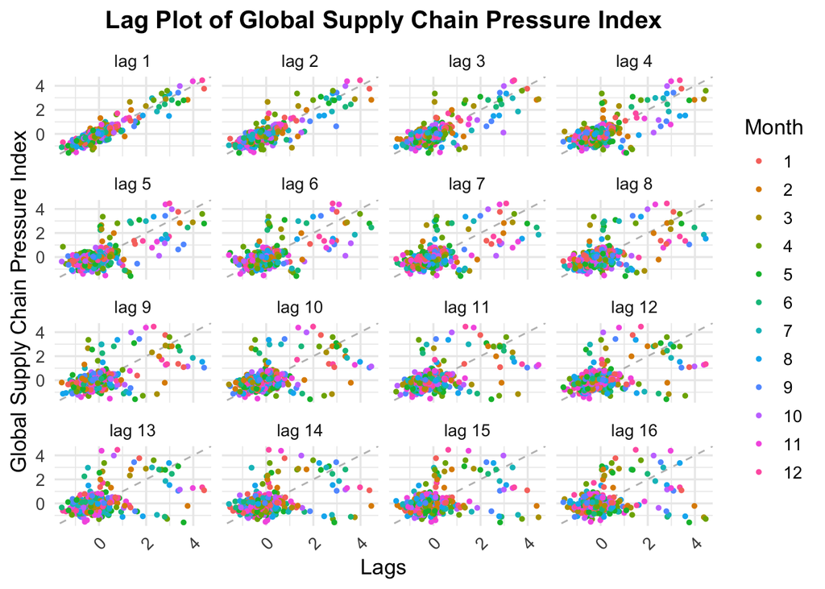

```r
gscpi_ts <- ts(gscpi$GSCPI, start = c(2000, 1), frequency = 12)
gglagplot(gscpi_ts, do.lines = FALSE) +
  xlab("Lags") +
  ylab("Global Supply Chain Pressure Index") +
  ggtitle("Lag Plot of Global Supply Chain Pressure Index") +
  scale_x_continuous(labels = comma) +
  scale_y_continuous(labels = comma) +
  theme_minimal(base_size = 13) +
  theme(
    axis.text.x = element_text(angle = 45, hjust = 1),
    plot.title = element_text(face = "bold", size = 15, hjust = 0.5)
  )
```

The lag plot of the Global Supply Chain Pressure Index (GSCPI) shows moderate positive autocorrelation at short lags, but this relationship weakens rapidly after lag 4. The scattered patterns at higher lags reflect short-term persistence rather than long-term memory, consistent with the transient nature of global supply disruptions. The lack of consistent seasonality suggests that shocks dissipate quickly, and differencing may be unnecessary once volatility is stabilized.

**AHS Weighted Average Tariff**